# PROJECT 2~ CODING CLUB

# PROJECT 2: CODING CLUB

Author:Weru Joan Nyokabi

### 1. Import the data to R in csv format(this is SPSS data) and name it financial_data.csv

### 2.clean the data before undertaking any analysis

```r
library(haven)
library(foreign)
library(tidyverse)
setwd("~/R- CLASS DATASETS")
finance<-read.spss("FinAccess_SPSS.sav",to.data.frame=TRUE,use.value.labels=TRUE)
View(finance)
```

### 3.Conduct exploratory analysis of the data and write a few bullet points on any descriptive statisics(summary statistics, tables and graphs) you find interesting and why you find them interesting

- We now want to see how monthly income differs among the different ages and different scales of financial literacy

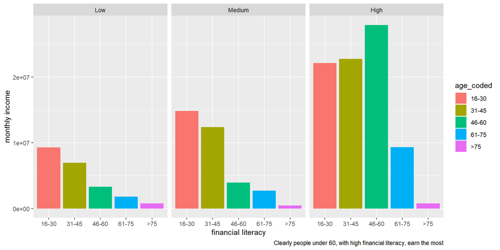

```r
library(ggplot2)
library(tigerstats)
finance%>%ggplot(aes(x=age_coded,y=monthly_income,fill=age_coded))+geom_col()+facet_wrap(~fin_literacy)+labs(caption = "Clearly people under 60, with high financial literacy, earn the most",x="financial literacy",y="monthly income" )
```

- We now check to see if people’s earnings differ in terms of their saving usage

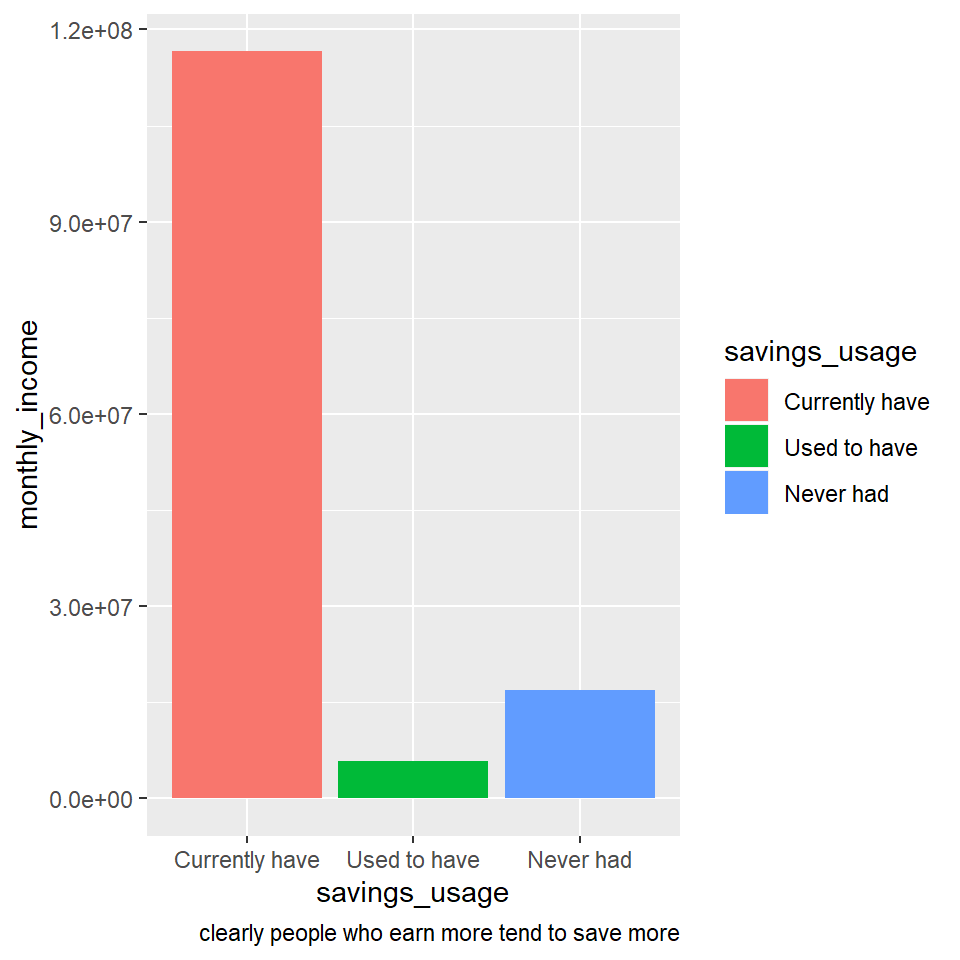

```r
ggplot(finance,aes(x=savings_usage,y=monthly_income,fill=savings_usage))+geom_col()+labs(caption = "clearly people who earn more tend to save more")
```

- We now seek to find out which age group has the highest financial literacy

```r
library(knitr)
library(tigerstats)
rowPerc(xtabs(~age_coded+fin_literacy,data=finance))%>%knitr::kable()
```

|  | Low | Medium | High | Total |
| --- | --- | --- | --- | --- |
| 16-30 | 34.69 | 36.55 | 28.76 | 100 |
| 31-45 | 30.73 | 36.70 | 32.57 | 100 |
| 46-60 | 36.78 | 34.26 | 28.97 | 100 |
| 61-75 | 54.44 | 26.78 | 18.79 | 100 |
| >75 | 73.67 | 17.79 | 8.54 | 100 |

*people in the 31-45 age group have the highest financial literacy*

### 4.Create a cross table of age_coded and cluster type

```r
library(gmodels)
ct<-CrossTable(finance$age_coded,finance$cluster_type)
```

```
##
##
##    Cell Contents
## |-------------------------|
## |                       N |
## | Chi-square contribution |
## |           N / Row Total |
## |           N / Col Total |
## |         N / Table Total |
## |-------------------------|
##
##
## Total Observations in Table:  8665
##
##
##                   | finance$cluster_type
## finance$age_coded |     Rural |     Urban | Row Total |
## ------------------|-----------|-----------|-----------|
##             16-30 |      1890 |      1976 |      3866 |
##                   |    34.879 |    44.383 |           |
##                   |     0.489 |     0.511 |     0.446 |
##                   |     0.390 |     0.518 |           |
##                   |     0.218 |     0.228 |           |
## ------------------|-----------|-----------|-----------|
##             31-45 |      1483 |      1130 |      2613 |
##                   |     0.269 |     0.342 |           |
##                   |     0.568 |     0.432 |     0.302 |
##                   |     0.306 |     0.296 |           |
##                   |     0.171 |     0.130 |           |
## ------------------|-----------|-----------|-----------|
##             46-60 |       803 |       426 |      1229 |
##                   |    19.156 |    24.376 |           |
##                   |     0.653 |     0.347 |     0.142 |
##                   |     0.165 |     0.112 |           |
##                   |     0.093 |     0.049 |           |
## ------------------|-----------|-----------|-----------|
##             61-75 |       467 |       209 |       676 |
##                   |    20.678 |    26.312 |           |
##                   |     0.691 |     0.309 |     0.078 |
##                   |     0.096 |     0.055 |           |
##                   |     0.054 |     0.024 |           |
## ------------------|-----------|-----------|-----------|
##               >75 |       209 |        72 |       281 |
##                   |    16.956 |    21.577 |           |
##                   |     0.744 |     0.256 |     0.032 |
##                   |     0.043 |     0.019 |           |
##                   |     0.024 |     0.008 |           |
## ------------------|-----------|-----------|-----------|
##      Column Total |      4852 |      3813 |      8665 |
##                   |     0.560 |     0.440 |           |
## ------------------|-----------|-----------|-----------|
##
##
```

### 5.Select the variables:age and monthly_income. Test for normality

We use the **Kolmogorov_Smirnov test** which checks whether the two sample data comes from the same distribution.

- D- value of the test statistic
- $H_o$(null hypothesis)- The two samples were drawn from the same population
- $H_1$(alternative hypotheses)- The two samples were not drawn from the same distribution
- p-value- a measure of strength of the evidence against the null hypothesis

```r
ks.test(finance$age,finance$monthly_income)
```

```
##
##  Two-sample Kolmogorov-Smirnov test
##
## data:  finance$age and finance$monthly_income
## D = 0.98107, p-value < 2.2e-16
## alternative hypothesis: two-sided
```

*our p-value is less than 0.05(level of significance) so we reject the null hypothesis and accept the alternative hypothesis; the two samples were not drawn from the same distribution*

#### if possible, does monthly income depend on the age of the respondents

```r
y<-finance[,"monthly_income"]
x<-finance[,"age"]
model1<-lm(y~x)
summary(model1)
```

```
##
## Call:
## lm(formula = y ~ x)
##
## Residuals:
##      Min       1Q   Median       3Q      Max
##   -27672   -12715    -9212    -1134 15131178
##
## Coefficients:
##             Estimate Std. Error t value Pr(>|t|)
## (Intercept)   9233.2     4796.2   1.925   0.0543 .
## x              184.4      117.8   1.566   0.1175
## ---
## Signif. codes:  0 '***' 0.001 '**' 0.01 '*' 0.05 '.' 0.1 ' ' 1
##
## Residual standard error: 181700 on 8663 degrees of freedom
## Multiple R-squared:  0.0002828,  Adjusted R-squared:  0.0001674
## F-statistic: 2.451 on 1 and 8663 DF,  p-value: 0.1175
```

*p-value is more than 0.05(level of significance),we accept the null hypothesis; there is no significant relationship between age and monthly income*

### 6.Select the categorical variables on age and monthly income. Perform a Chi_square test. State what you are testing and your findings.

- $H_0$- The two variables are independent
- $H_1$-The two variabes relate to each other

```r
cq<-chisq.test(finance$age,finance$monthly_income)
cq
```

```
##
##  Pearson's Chi-squared test
##
## data:  finance$age and finance$monthly_income
## X-squared = 39095, df = 39093, p-value = 0.4956
```

*Our p-value is more than 0.05(level of significance) so we accept the null hypothesis and conclude that our two variables are independent*

### 7.Perform a one way ANOVA between monthly income and highest education of the respondent. Does monthly income depend on the level of education?

- $H_o$-The means between groups are identical
- $H_1$ least the mean of one group is different
- F-statistic= Variation among sample means/variation within groups; there is a relationship between the groups

```r
anova1<-aov(finance$monthly_income~finance$education)
summary(anova1)
```

```
##                     Df    Sum Sq   Mean Sq F value   Pr(>F)
## finance$education    3 2.241e+12 7.470e+11    22.8 1.07e-14 ***
## Residuals         8661 2.838e+14 3.276e+10
## ---
## Signif. codes:  0 '***' 0.001 '**' 0.01 '*' 0.05 '.' 0.1 ' ' 1
```

*Our p-value is less than our level of significance(0.05) we therefore reject the null hypothesis and conclude that monthly income does indeed depend on education*

### 8.Test for statistical significance using one sample t test to find out if the average income is less than Kshs.15,000?

- $H_0$-true mean is greater or equal to 15000
- $H_1$true mean is less than 15,000

```r
t.test(finance$monthly_income,mu=15000,alternative = "less")
```

```
##
##  One Sample t-test
##
## data:  finance$monthly_income
## t = 0.55951, df = 8664, p-value = 0.7121
## alternative hypothesis: true mean is less than 15000
## 95 percent confidence interval:
##      -Inf 19302.81
## sample estimates:
## mean of x
##  16092.05
```

*Our p value is more than 0.05(level of significance) we accept the null and conclude average income is greater than or equal to 15,000*

### 9.Using the generalized linear model, perform the following

- a)Does mobile usage depend on gender, religion, education and credit usage
- b)Does bank usage depend on financial literacy, numeracy, savings usage and credit usage

```r
attach(finance)
```